# Untitled

David Selby

2024-04-02

# Learners

## XGBOOST S-LEARNER

xgboost_s_alg: Implementation of XGBOOST S-Learner  
Implemented using the package  
@description S-learner treats the treatment variable as if it was just another covariate like those in the vector x_tr. Instead of having two models for the response as a function of the covariates x_tr, the S-learner has a single model for the response as a function of x_tr and the treatment d_tr. But d_tr has interactions with the covariates. This is achieved by augmenting the covariates matrix with interaction terms, specifically by adjusting the treatment variable to center it around 0 and then multiplying it element-wise with the original covariates. These interactions enable the model to capture how the effects of certain covariates may vary based on the treatment received. XGBoost, or eXtreme Gradient Boosting, is a model that uses a technique called gradient boosting to build an ensemble of decision trees for both regression and classification tasks.  
@param x_tr Matrix of training covariates (N x X matrix)  
@param y_tr Vector of outcome values  
@param d_tr Vector of treatment indicators in training data  
@param x_val Matrix of validation covariates (N x X matrix)  
@import xnie/rlearner  
@return Returns predicted IATEs of the validation sample  
@export

## XGBOOST T-LEARNER

xgboost_t_alg: Implementation of XGBOOST T-Learner  
Implemented using the package  
@description T-learner learns the treated and control expected outcome respectively by fitting two separate models and taking the difference between outcomes. XGBoost, or eXtreme Gradient Boosting, is a model that uses a technique called gradient boosting to build an ensemble of decision trees for both regression and classification task.  
@param x_tr Matrix of training covariates (N x X matrix)  
@param y_tr Vector of outcome values  
@param d_tr Vector of treatment indicators in training data  
@param x_val Matrix of validation covariates (N x X matrix)  
@import xnie/rlearner  
@return Returns predicted IATEs of the validation sample  
@export

## XGBOOST R-LEARNER

xgboost_r_alg: Implementation of XGBOOST R-Learner  
Implemented using the package  
@description The R-learner estimates tau by combining models that predict both the outcome and the propensity score. We first fit and predict model on outcome. Then fit and predict model on treatment as outcome to calculate the propensity score. Then the function calculates the residuals by subtracting the predicted values from the actual outcomes and the predicted propensity scores from the actual treatment assignments, respectively. Then the pseudo-outcome is computed by dividing the residual of the outcome by the residual of the treatment assignment. This pseudo-outcome represents the estimated treatment effect for each observation. Then we fit the model on pseudo-outcome using the square of the residuals of the treatment assignment as weights. This adjustment in outcome helps to account for any potential confounding variables that may affect both the treatment assignment and the outcome. This weighting scheme ensures that observations with larger treatment assignment residuals have more influence in estimating the treatment effect. This approach allows us to obtain more reliable estimates of the treatment effect that are less biased by confounding variables.This approach allows us to obtain more reliable estimates of the treatment effect that are less biased by confounding variables. XGBoost, or eXtreme Gradient Boosting, is a model that uses a technique called gradient boosting to build an ensemble of decision trees for both regression and classification tasks.  
@param x_tr Matrix of training covariates (N x X matrix)  
@param y_tr Vector of outcome values  
@param d_tr Vector of treatment indicators in training data  
@param x_val Matrix of validation covariates (N x X matrix)  
@import xnie/rlearner  
@return Returns predicted IATEs of the validation sample  
@export

# Setup Models

cf_model: Implementation of CF model using the package causal forest estimates the impact of a treatment or intervention by combining random forest techniques with causal inference principles. It builds an ensemble of decision trees, each trained on different subsets of the data, to estimate individualized treatment effects based on subjects’ characteristics (covariates). These individual estimates are then aggregated to provide an overall assessment of the treatment’s impact while accounting for potential confounding factors, making it a valuable tool for causal analysis in observational data. / / @param x_tr Matrix of training covariates (N x X matrix) / @param y_tr Vector of outcome values in training data / @param d_tr Vector of treament indicators in training data / @param x_val Matrix of validation covariates (N x X matrix) / @param ntrain N of rows in training data / @import grf / / @return Returns predicted IATEs of the validation sample / / @export /

# Predicted Values Exploration

## Descriptive Statistics

Binary Outcome

```
##             n mean median   min max
## C16BMVDEG 896 0.11   0.11 -0.01 0.2
```

```
##    estimate  std_error  t_value        pr_t   lower_ci  upper_ci significant
## . 0.1136744 0.03579932 3.175324 0.001559864 0.04350777 0.1838411           1
```

Continous OUtcome

```
## CATE
```

```
##              n mean median   min   max
## X16BTMCRET 896 7.88   8.64 -6.43 16.01
```

```
## lm
```

```
##   estimate std_error  t_value       pr_t  lower_ci upper_ci significant
## . 6.944811  3.366514 2.062909 0.03947591 0.3464434 13.54318           1
```

## Histogram

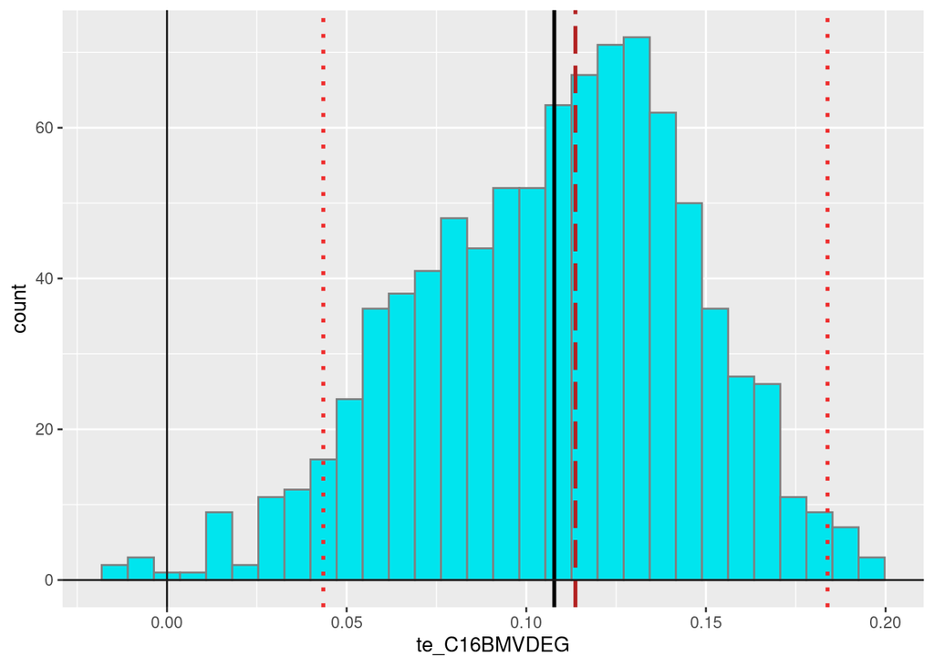

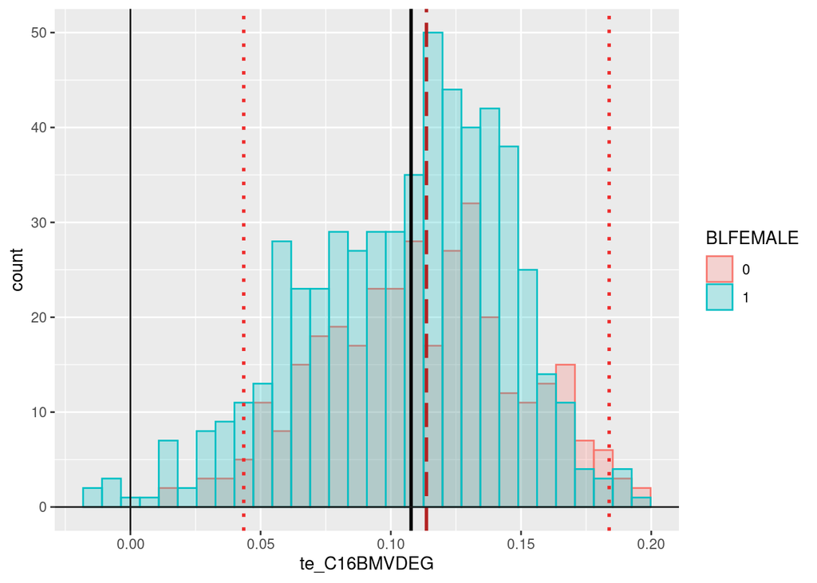

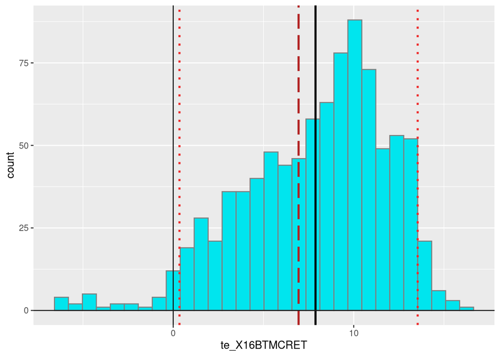

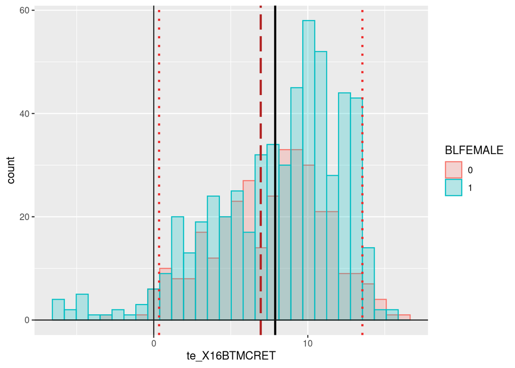